# Zotero Tag Extraction

This script extracts the tags from a Zotero library export, counts how often each tag is used in the library, then exports the results to a CSV file.

To export the citation data from Zotero, right-click the library in the Zotero desktop application and select *Export Library*. Use the CSV format.

The script code is posted [in a GitHub gist](https://gist.github.com/jered0/a2881b422f813d725e4fcccb0013ac92). That code won't have all the `head()` commands in it that show what the data looks like at each step (by printing the first few lines of data).

The script starts by loading a library it uses, then it imports the data using the `read.csv()` function.

```r
library(tidyverse)

zexport <- read.csv("LIS5703_sp19_burnett.csv", header = TRUE)
head(zexport)
```

| ï..Key | Item.Type | Publication.Year | Author | Title | Publication.Title | ISBN | ISSN | DOI | Url | ... | Programming.Language | Version | System | Code | Code.Number | Section | Session | Committee | History | Legislative.Body |
| --- | --- | --- | --- | --- | --- | --- | --- | --- | --- | --- | --- | --- | --- | --- | --- | --- | --- | --- | --- | --- |
| WS9986IF | bookSection | 2013 |  | Resource description and metadata. Ch. 4 | The Discipline of Organizing. |  |  |  | http://disciplineoforganizing.org/tdo-v-1-2013/ | ... | NA | NA | NA | NA | NA | NA | NA | NA | NA | NA |
| 9DRSU9XX | journalArticle | 2013 | Fee, William | Where Is the Justiceâ€¦ League?: Graphic Novel Cataloging and Classification | Serials Review |  | 0098-7913 | 10.1016/j.serrev.2013.02.004 | http://eds.b.ebscohost.com.proxy.lib.fsu.edu/eds/detail/detail?vid=3&sid=359fa31d-2e3b-46eb-97c8-156d83153122%40pdc-v-sessmgr01&bdata=JnNpdGU9ZWRzLWxpdmU%3d#AN=S009879131300018X&db=edselp | ... | NA | NA | NA | NA | NA | NA | NA | NA | NA | NA |
| UW2VNDKM | journalArticle | 2004 | Guenther, Rebecca S. | Using the Metadata Object Description Schema (MODS) for resource description: guidelines and applications | Library Hi Tech |  | 0737-8831 | 10.1108/07378830410524530 | https://www-emeraldinsight-com.proxy.lib.fsu.edu/doi/full/10.1108/07378830410524530 | ... | NA | NA | NA | NA | NA | NA | NA | NA | NA | NA |
| SA8GBJ6F | journalArticle | 2014 | Gherardelli, Monica; Adembri, Giulia; Balleri, Rita; Di Tondo, Sergio | Methods and tools for the classification and cataloging of antique moulds from the collection of the Richard-Ginori factory | Journal of Cultural Heritage |  | 12962074 | 10.1016/j.culher.2013.11.001 | https://linkinghub.elsevier.com/retrieve/pii/S1296207413002100 | ... | NA | NA | NA | NA | NA | NA | NA | NA | NA | NA |
| PUNVLD44 | book | 2008 | Maxwell, Robert L. | FRBR: A Guide for the Perplexed |  | 9780838909508 (alk. paper) 0838909507 (alk. paper) 9780838909508 (pbk.) 0838909507 (pbk.) 0838909507 (pbk. : alk. paper) 9780838909508 (pbk. : alk. paper) |  |  | http://eds.b.ebscohost.com.proxy.lib.fsu.edu/eds/detail/detail?vid=1&sid=1326756d-e7d3-4691-ae50-094f92e3b434%40sessionmgr102&bdata=JnNpdGU9ZWRzLWxpdmU%3d#AN=fsu.020174214&db=cat05720a | ... | NA | NA | NA | NA | NA | NA | NA | NA | NA | NA |
| YCRGBSDB | journalArticle | 2018 | Ward, Mark; Saarti, Jarmo | Reviewing, Rebutting, and Reimagining Fiction Classification | Cataloging & Classification Quarterly |  | 0163-9374, 1544-4554 | 10.1080/01639374.2017.1411414 | https://www.tandfonline.com/doi/full/10.1080/01639374.2017.1411414 | ... | NA | NA | NA | NA | NA | NA | NA | NA | NA | NA |

At this point there are duplicates in the data because of a syncing error. We can see that when we sort by title.

```r
head(zexport[order(zexport$Title),])
```

|  | ï..Key | Item.Type | Publication.Year | Author | Title | Publication.Title | ISBN | ISSN | DOI | Url | ... | Programming.Language | Version | System | Code | Code.Number | Section | Session | Committee | History | Legislative.Body |
| --- | --- | --- | --- | --- | --- | --- | --- | --- | --- | --- | --- | --- | --- | --- | --- | --- | --- | --- | --- | --- | --- |
| 88 | GSKR6E9G | journalArticle | 2015 | Steiner, Elisabeth, Koch, Carina | "A Digital Archive of Cultural Heritage Objects: Standardized Metadata and Annotation Categories" | New Review of Information Networking |  |  |  | https://login.proxy.lib.fsu.edu/login?url=http://search.ebscohost.com/login.aspx?direct=true&db=edb&AN=111800033&site=eds-live | ... | NA | NA | NA | NA | NA | NA | NA | NA | NA | NA |
| 227 | 5ID7TV7Q | journalArticle | 2015 | Steiner, Elisabeth, Koch, Carina | "A Digital Archive of Cultural Heritage Objects: Standardized Metadata and Annotation Categories" | New Review of Information Networking |  |  |  | https://login.proxy.lib.fsu.edu/login?url=http://search.ebscohost.com/login.aspx?direct=true&db=edb&AN=111800033&site=eds-live | ... | NA | NA | NA | NA | NA | NA | NA | NA | NA | NA |
| 228 | Z4PI77HA | journalArticle | 2015 | Steiner, Elisabeth, Koch, Carina | "A Digital Archive of Cultural Heritage Objects: Standardized Metadata and Annotation Categories" | New Review of Information Networking |  |  |  | https://login.proxy.lib.fsu.edu/login?url=http://search.ebscohost.com/login.aspx?direct=true&db=edb&AN=111800033&site=eds-live | ... | NA | NA | NA | NA | NA | NA | NA | NA | NA | NA |
| 518 | GF4KP98B | journalArticle | 2016 | Kiu, Ching Chieh | "Automatic Tags Generation in Folksonomy for Learning Resources Reuse and Sharing" | Pertanika Journal of Science & Technology |  |  |  |  | ... | NA | NA | NA | NA | NA | NA | NA | NA | NA | NA |
| 131 | BVP3WQ2D | journalArticle | 2015 | MYNTTI, J. jeremy, NEATROUR, A | "Use Existing Data First: Reconcile Metadata before Creating New Controlled Vocabularies" | Journal of Library Metadata |  |  |  | http://search.ebscohost.com.proxy.lib.fsu.edu/login.aspx?direct=true&db=eue&AN=112288279&site=eds-live&scope=site | ... | NA | NA | NA | NA | NA | NA | NA | NA | NA | NA |
| 67 | DRV8JWSJ | journalArticle | 2012 | Taheri, Sayyed Mahdi; Hariri, Nadjla | A comparative study on the indexing and ranking of the content objects including the MARCXML and Dublin Core's metadata elements by general search engines | The Electronic Library |  | 0264-0473 | 10.1108/02640471211252193 | https://www-emeraldinsight-com.proxy.lib.fsu.edu/doi/pdfplus/10.1108/02640471211252193 | ... | NA | NA | NA | NA | NA | NA | NA | NA | NA | NA |

To fix that, the script sorts the data by date modified (so the most recent entry will be kept when there's a duplicate). The `!` is a negation, so `!duplicated` in the next line selects the rows that aren't duplicates and puts them in `ztrimmed`. It uses the author, title, and manual tags columns to determine duplicates (using the tags column ensures that if two students posted the same article, the extra entry won't be deleted). The result eliminates the duplicates we saw when we sorted by title.

```r
zsorted <- zexport[order(zexport$Date.Modified, decreasing = TRUE),]
ztrimmed <- zsorted[!duplicated(zsorted[,c("Author", "Title", "Manual.Tags")]),]
head(ztrimmed[order(ztrimmed$Title),])
```

|  | ï..Key | Item.Type | Publication.Year | Author | Title | Publication.Title | ISBN | ISSN | DOI | Url | ... | Programming.Language | Version | System | Code | Code.Number | Section | Session | Committee | History | Legislative.Body |
| --- | --- | --- | --- | --- | --- | --- | --- | --- | --- | --- | --- | --- | --- | --- | --- | --- | --- | --- | --- | --- | --- |
| 227 | 5ID7TV7Q | journalArticle | 2015 | Steiner, Elisabeth, Koch, Carina | "A Digital Archive of Cultural Heritage Objects: Standardized Metadata and Annotation Categories" | New Review of Information Networking |  |  |  | https://login.proxy.lib.fsu.edu/login?url=http://search.ebscohost.com/login.aspx?direct=true&db=edb&AN=111800033&site=eds-live | ... | NA | NA | NA | NA | NA | NA | NA | NA | NA | NA |
| 518 | GF4KP98B | journalArticle | 2016 | Kiu, Ching Chieh | "Automatic Tags Generation in Folksonomy for Learning Resources Reuse and Sharing" | Pertanika Journal of Science & Technology |  |  |  |  | ... | NA | NA | NA | NA | NA | NA | NA | NA | NA | NA |
| 131 | BVP3WQ2D | journalArticle | 2015 | MYNTTI, J. jeremy, NEATROUR, A | "Use Existing Data First: Reconcile Metadata before Creating New Controlled Vocabularies" | Journal of Library Metadata |  |  |  | http://search.ebscohost.com.proxy.lib.fsu.edu/login.aspx?direct=true&db=eue&AN=112288279&site=eds-live&scope=site | ... | NA | NA | NA | NA | NA | NA | NA | NA | NA | NA |
| 334 | YRGMIUTU | journalArticle | 2012 | Taheri, Sayyed Mahdi; Hariri, Nadjla | A comparative study on the indexing and ranking of the content objects including the MARCXML and Dublin Core's metadata elements by general search engines | The Electronic Library |  | 0264-0473 | 10.1108/02640471211252193 | https://www-emeraldinsight-com.proxy.lib.fsu.edu/doi/pdfplus/10.1108/02640471211252193 | ... | NA | NA | NA | NA | NA | NA | NA | NA | NA | NA |
| 323 | 34WCL2V4 | journalArticle | 2016 | Jett, Jacob; Sacchi, Simone; Lee, Jin Ha; Clarke, Rachel Ivy | A conceptual model for video games and interactive media | Journal of the Association for Information Science & Technology |  | 2330-1635 | 10.1002/asi.23409 | http://eds.a.ebscohost.com.proxy.lib.fsu.edu/eds/pdfviewer/pdfviewer?vid=5&sid=57962425-74c5-4c82-a5f8-d130aa84f870%40sessionmgr4006 | ... | NA | NA | NA | NA | NA | NA | NA | NA | NA | NA |
| 473 | N45RETUZ | journalArticle | 2015 | Lau, Simon Boung-Yew; Lee, Chien-Sing; Singh, Yashwant Prasad | A folksonomy-based lightweight resource annotation metadata schema for personalized hypermedia learning resource delivery | Interactive Learning Environments |  | 1049-4820 | 10.1080/10494820.2012.745429 | https://doi.org/10.1080/10494820.2012.745429 | ... | NA | NA | NA | NA | NA | NA | NA | NA | NA | NA |

Next, extract the manual and automatic tag columns and merge them into a single "tags" column.

```r
tagsraw <- data.frame(tags = unlist(ztrimmed[,c("Manual.Tags", "Automatic.Tags")], use.names = FALSE))
head(tagsraw)
```

| tags |
| --- |
| metadata; zCummingsAlora; Subjects; tagging; Contribute 5; user-generated tags |
| zPierreLivia; Contribute 5; Folksonomy; Subject; Library Catalogs; Public Library |
| zHagaman Kristin; Subjects; Contribute 5; Controlled Vocabulary |
| Subjects; Contribute 5; Folksonomy; Collaborative tagging; Pragmatism; zPlay L |
| zRobayoJessica; folksonomy; Subjects; Contribute 5; social tagging; user tagging |

Now we have a bunch of semicolon-separated tag lists, so the script splits the entries in the tag columns to get one tag per row. The result is a flat list of tags, which is why the output looks different.

```r
tagslist <- unnest(tagsraw, tags = strsplit(as.character(tagsraw$tags), "; "))
colnames(tagslist) <- "tag"
head(tagslist[order(tagslist),])
```

1. '3D objects'

2. '3D Objects'

3. '3D Objects'

4. 'AACR2'

5. 'AACR2'

6. 'Abstract items'

Now the tags can be counted. That's done by sorting the list, then using `group_by()` plus `tally()` to get a table with tags in one column and their tallies in another.

```r
tagcount <- data.frame(tag = tagslist[order(tagslist),]) %>%
  group_by(tag) %>%
  tally
head(tagcount)
```

| tag | n |
| --- | --- |
| 3D objects | 1 |
| 3D Objects | 2 |
| AACR2 | 2 |
| Abstract items | 1 |
| Academic libraries | 1 |
| Academic Library Admistration | 1 |

Finally, export the tags and counts to a new CSV file.

```r
write_csv(tagcount, "LIS5703 Tags with Totals.csv")
```

And just for fun, this is how easy it is to make a nice chart in R.

First we extract the top nine tags (leaving out the tags that identified the assignment, they don't count).

```r
toptags <- tagcount[order(tagcount$n, decreasing = TRUE),]
toptags <- toptags[7:15,]
toptags
```

| tag | n |
| --- | --- |
| Metadata | 26 |
| metadata | 15 |
| Cataloging | 14 |
| Folksonomy | 12 |
| Digital libraries | 10 |
| Dublin Core | 10 |
| Folksonomies | 10 |
| MARC | 9 |
| tagging | 9 |

And this is the command that makes the chart (broken into several lines to make it easier to read).

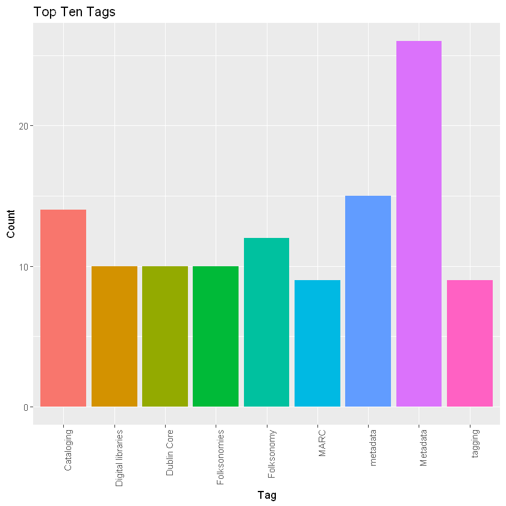

```r
ggplot(toptags, aes(x=tag, y=n, fill=tag)) +
  geom_bar(stat="identity") +
  theme(axis.text.x = element_text(angle = 90, hjust = 1), legend.position = "none") +
  labs(title="Top Ten Tags", x = "Tag", y = "Count")
```